# 03-Models for 2yr dataset

Francisco E. Fonturbel

16/ago/2023

## Anthropogenic effects on chungungo’s abundance

Here we will explore some anthropogenic variables as potential drivers of abundance change on this species

Let’s do some nice ggplots to examine our data before fitting fancy models:

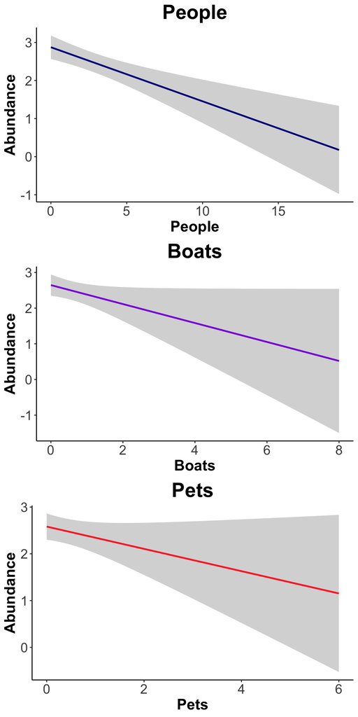

How is our **response varible** distributed?

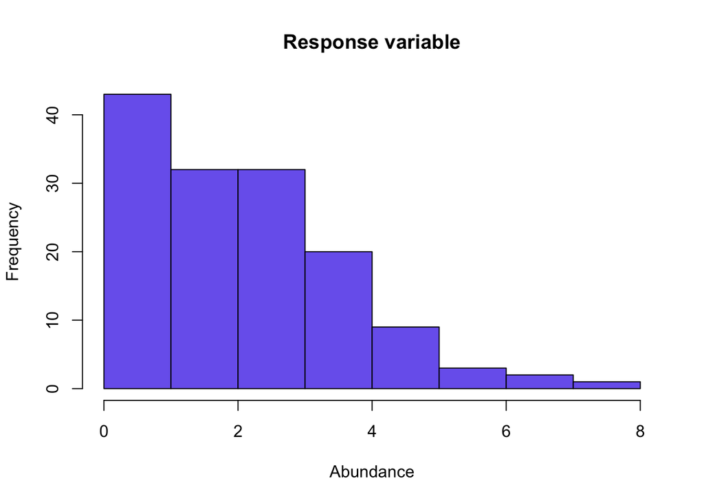

Well, our response variable is not normal, as abundance is a count variable with positive integers. Therefore, we should use *Poisson* or *negative binomial* distributions instead.

## Individual models

Although is not the best option, we will try to fit some glms for each individual predictor variable depicted in the plots above.

### People

```
##
## Call:
## glm(formula = abund ~ people, family = "poisson")
##
## Deviance Residuals:
##      Min        1Q    Median        3Q       Max
## -2.41963  -0.70172   0.04231   0.59355   2.56938
##
## Coefficients:
##             Estimate Std. Error z value Pr(>|z|)
## (Intercept)  1.07408    0.06255  17.172  < 2e-16 ***
## people      -0.07134    0.01825  -3.909 9.25e-05 ***
## ---
## Signif. codes:  0 '***' 0.001 '**' 0.01 '*' 0.05 '.' 0.1 ' ' 1
##
## (Dispersion parameter for poisson family taken to be 1)
##
##     Null deviance: 164.17  on 141  degrees of freedom
## Residual deviance: 146.28  on 140  degrees of freedom
## AIC: 510.82
##
## Number of Fisher Scoring iterations: 5
```

Let’s test our count variable for overdispersion before continuing…

```
##
##  Overdispersion test
##
## data:  modp
## z = -0.57178, p-value = 0.7163
## alternative hypothesis: true dispersion is greater than 1
## sample estimates:
## dispersion
##  0.9368539
```

No overdispersion, we can go with Poisson distribution hereafter.

### Boats

```
##
## Call:
## glm(formula = abund ~ boats, family = "poisson")
##
## Deviance Residuals:
##     Min       1Q   Median       3Q      Max
## -2.3093  -0.9875  -0.2255   0.4159   2.6290
##
## Coefficients:
##             Estimate Std. Error z value Pr(>|z|)
## (Intercept)  0.98077    0.05997  16.353   <2e-16 ***
## boats       -0.13231    0.06707  -1.973   0.0485 *
## ---
## Signif. codes:  0 '***' 0.001 '**' 0.01 '*' 0.05 '.' 0.1 ' ' 1
##
## (Dispersion parameter for poisson family taken to be 1)
##
##     Null deviance: 164.17  on 141  degrees of freedom
## Residual deviance: 159.69  on 140  degrees of freedom
## AIC: 524.24
##
## Number of Fisher Scoring iterations: 5
```

### Pets

```
##
## Call:
## glm(formula = abund ~ pets, family = "poisson")
##
## Deviance Residuals:
##     Min       1Q   Median       3Q      Max
## -2.2749  -1.1286  -0.2068   0.7630   2.6897
##
## Coefficients:
##             Estimate Std. Error z value Pr(>|z|)
## (Intercept)  0.95072    0.05564  17.086   <2e-16 ***
## pets        -0.11485    0.07096  -1.618    0.106
## ---
## Signif. codes:  0 '***' 0.001 '**' 0.01 '*' 0.05 '.' 0.1 ' ' 1
##
## (Dispersion parameter for poisson family taken to be 1)
##
##     Null deviance: 164.17  on 141  degrees of freedom
## Residual deviance: 161.18  on 140  degrees of freedom
## AIC: 525.73
##
## Number of Fisher Scoring iterations: 5
```

## Models

To do this, we will use a Poisson GLMM, using sampling month as a random factor (month nested within year).

```
## Generalized linear mixed model fit by maximum likelihood (Laplace
##   Approximation) [glmerMod]
##  Family: poisson  ( log )
## Formula: abund ~ people + boats + pets + (month | year)
##
##      AIC      BIC   logLik deviance df.resid
##    666.2    908.5   -251.1    502.2       60
##
## Scaled residuals:
##      Min       1Q   Median       3Q      Max
## -1.61836 -0.66018 -0.07729  0.70690  2.90952
##
## Random effects:
##  Groups Name        Variance Std.Dev. Corr
##  year   (Intercept) 0.000000 0.00000
##         monthaug    0.072936 0.27007    NaN
##         monthdec    0.028554 0.16898    NaN  0.51
##         monthfeb    0.003110 0.05577    NaN -0.96 -0.72
##         monthjan    0.006157 0.07846    NaN -0.49 -1.00  0.71
##         monthjul    0.019951 0.14125    NaN  0.26  0.96 -0.52 -0.97
##         monthjun    0.014621 0.12092    NaN -0.12 -0.92  0.39  0.93 -0.99
##         monthmar    0.022728 0.15076    NaN -1.00 -0.45  0.94  0.43 -0.20  0.06
##         monthmay    0.041342 0.20333    NaN -0.92 -0.81  0.99  0.80 -0.63  0.51
##         monthnov    0.029098 0.17058    NaN -0.98 -0.30  0.88  0.28 -0.04 -0.10
##         monthoct    0.027075 0.16454    NaN -0.72  0.23  0.50 -0.25  0.48 -0.60
##         monthsep    0.026575 0.16302    NaN  0.33 -0.64 -0.06  0.66 -0.82  0.89
##
##
##
##
##
##
##
##
##
##   0.89
##   0.99  0.81
##   0.77  0.38  0.86
##  -0.40  0.07 -0.53 -0.89
## Number of obs: 142, groups:  year, 2
##
## Fixed effects:
##             Estimate Std. Error z value Pr(>|z|)
## (Intercept)  1.07661    0.09295  11.583  < 2e-16 ***
## people      -0.05943    0.02160  -2.752  0.00592 **
## boats       -0.10178    0.07552  -1.348  0.17777
## pets        -0.01137    0.08499  -0.134  0.89359
## ---
## Signif. codes:  0 '***' 0.001 '**' 0.01 '*' 0.05 '.' 0.1 ' ' 1
##
## Correlation of Fixed Effects:
##        (Intr) people boats
## people -0.251
## boats  -0.195 -0.310
## pets   -0.037 -0.472  0.149
## optimizer (Nelder_Mead) convergence code: 4 (failure to converge in 10000 evaluations)
## boundary (singular) fit: see help('isSingular')
## failure to converge in 10000 evaluations
```

```
## Global model call: glmer(formula = abund ~ people + boats + pets + (month | year),
##     family = "poisson", na.action = "na.fail")
## ---
## Model selection table
##   (Intrc)    peopl df   logLik   BIC delta weight
## 3   1.058 -0.06921 80 -251.525 899.5     0      1
## Models ranked by BIC(x)
## Random terms (all models):
##   month | year
```

[output not shown]

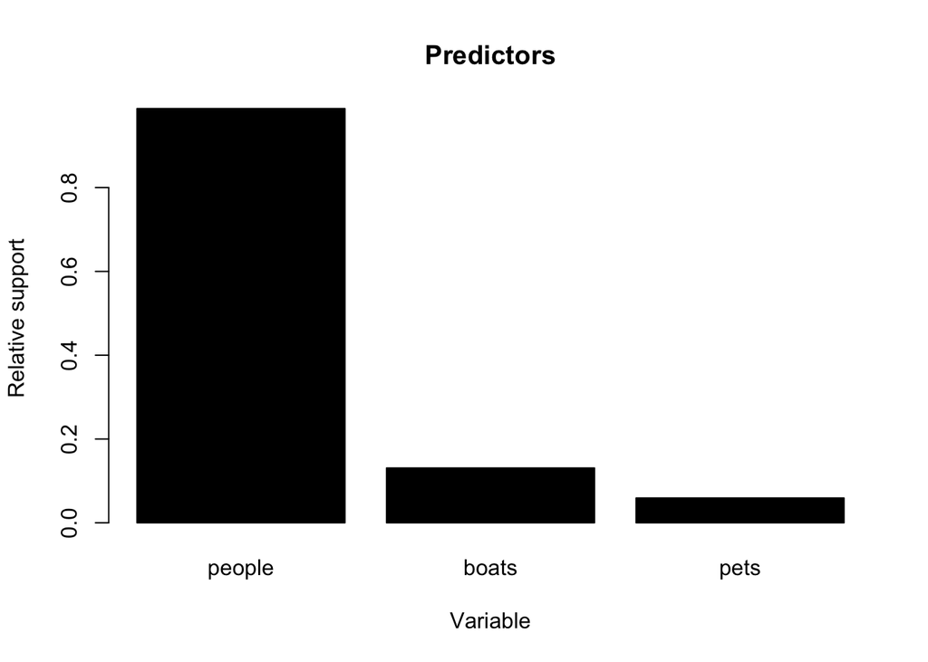

As predicted, people is the most relevant variable in our models.

```
## Global model call: glmer(formula = abund ~ people + boats + pets + (month | year),
##     family = "poisson", na.action = "na.fail")
## ---
## Model selection table
##   (Intrc)   boats    peopl      pets df   logLik   BIC delta weight
## 3  1.0580         -0.06921           80 -251.525 899.5  0.00  0.825
## 4  1.0760 -0.1003 -0.06081           81 -251.087 903.6  4.08  0.107
## 7  1.0500         -0.06925  0.005596 81 -252.067 905.6  6.04  0.040
## 8  1.0910 -0.1035 -0.05950 -0.014490 82 -250.508 907.4  7.88  0.016
## 2  0.9815 -0.1692                    80 -256.519 909.5  9.99  0.006
## 1  0.8939                            79 -259.646 910.8 11.29  0.003
## 6  1.0070 -0.1721          -0.136300 81 -255.125 911.7 12.15  0.002
## 5  0.9292                  -0.133300 80 -258.297 913.1 13.54  0.001
## Models ranked by BIC(x)
## Random terms (all models):
##   month | year
```

## Using disturbance indices

We made two disturbance indices upon the disturbance levels measured.

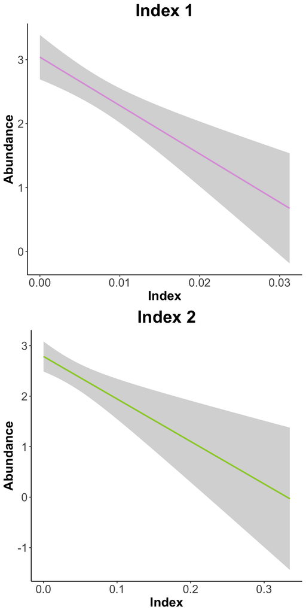

Now, we will use those indices instead of the raw variables… let’s see:

#### Index 1

```
## Generalized linear mixed model fit by maximum likelihood (Laplace
##   Approximation) [glmerMod]
##  Family: poisson  ( log )
## Formula: abund ~ index_1 + (month | year)
##
##      AIC      BIC   logLik deviance df.resid
##    661.1    897.6   -250.6    501.1       62
##
## Scaled residuals:
##      Min       1Q   Median       3Q      Max
## -1.54418 -0.69191 -0.05626  0.54797  3.02540
##
## Random effects:
##  Groups Name        Variance  Std.Dev. Corr
##  year   (Intercept) 0.0000000 0.00000
##         monthaug    0.0839394 0.28972    NaN
##         monthdec    0.0278137 0.16677    NaN  0.34
##         monthfeb    0.0007949 0.02819    NaN -0.89 -0.73
##         monthjan    0.0058398 0.07642    NaN -0.57 -0.97  0.89
##         monthjul    0.0343379 0.18530    NaN  0.17  0.98 -0.60 -0.91
##         monthjun    0.0207461 0.14404    NaN -0.06 -0.96  0.51  0.85 -0.99
##         monthmar    0.0247662 0.15737    NaN -0.99 -0.43  0.93  0.65 -0.27
##         monthmay    0.0352974 0.18788    NaN -0.89 -0.73  1.00  0.88 -0.59
##         monthnov    0.0346686 0.18620    NaN -0.99 -0.24  0.83  0.48 -0.07
##         monthoct    0.0299083 0.17294    NaN -0.82  0.25  0.47  0.01  0.42
##         monthsep    0.0346822 0.18623    NaN  0.34 -0.77  0.13  0.58 -0.87
##
##
##
##
##
##
##
##
##   0.16
##   0.50  0.94
##  -0.04  0.98  0.84
##  -0.52  0.76  0.48  0.88
##   0.92 -0.24  0.12 -0.43 -0.81
## Number of obs: 142, groups:  year, 2
##
## Fixed effects:
##              Estimate Std. Error z value Pr(>|z|)
## (Intercept)   1.11558    0.09994   11.16  < 2e-16 ***
## index_1     -35.33605    8.41311   -4.20 2.67e-05 ***
## ---
## Signif. codes:  0 '***' 0.001 '**' 0.01 '*' 0.05 '.' 0.1 ' ' 1
##
## Correlation of Fixed Effects:
##         (Intr)
## index_1 -0.451
## optimizer (Nelder_Mead) convergence code: 4 (failure to converge in 10000 evaluations)
## boundary (singular) fit: see help('isSingular')
## failure to converge in 10000 evaluations
```

#### Index 2

```
## Generalized linear mixed model fit by maximum likelihood (Laplace
##   Approximation) [glmerMod]
##  Family: poisson  ( log )
## Formula: abund ~ index_2 + (month | year)
##
##      AIC      BIC   logLik deviance df.resid
##    666.0    902.5   -253.0    506.0       62
##
## Scaled residuals:
##      Min       1Q   Median       3Q      Max
## -1.68523 -0.69407 -0.06633  0.60104  2.85251
##
## Random effects:
##  Groups Name        Variance Std.Dev. Corr
##  year   (Intercept) 0.000000 0.00000
##         monthaug    0.079657 0.28224    NaN
##         monthdec    0.023981 0.15486    NaN  0.56
##         monthfeb    0.007005 0.08369    NaN -0.96 -0.76
##         monthjan    0.009686 0.09842    NaN -0.29 -0.96  0.53
##         monthjul    0.009465 0.09729    NaN  0.18  0.92 -0.44 -0.99
##         monthjun    0.010567 0.10280    NaN -0.13 -0.90  0.39  0.99 -1.00
##         monthmar    0.018371 0.13554    NaN -0.99 -0.65  0.99  0.40 -0.30  0.25
##         monthmay    0.036026 0.18981    NaN -0.95 -0.78  1.00  0.56 -0.47  0.42
##         monthnov    0.022869 0.15122    NaN -0.97 -0.33  0.86  0.03  0.08 -0.13
##         monthoct    0.031728 0.17812    NaN -0.79  0.07  0.60 -0.36  0.46 -0.50
##         monthsep    0.016580 0.12877    NaN  0.47 -0.47 -0.22  0.71 -0.78  0.82
##
##
##
##
##
##
##
##
##
##   0.98
##   0.93  0.85
##   0.71  0.57  0.92
##  -0.36 -0.18 -0.68 -0.91
## Number of obs: 142, groups:  year, 2
##
## Fixed effects:
##             Estimate Std. Error z value Pr(>|z|)
## (Intercept)  1.02105    0.08552  11.939  < 2e-16 ***
## index_2     -4.44780    1.30850  -3.399 0.000676 ***
## ---
## Signif. codes:  0 '***' 0.001 '**' 0.01 '*' 0.05 '.' 0.1 ' ' 1
##
## Correlation of Fixed Effects:
##         (Intr)
## index_2 -0.360
## optimizer (Nelder_Mead) convergence code: 0 (OK)
## boundary (singular) fit: see help('isSingular')
```

Both models are significant, but index1 seems nicer than index2.